# reprudible-research-1

Javad Hashtroudian

June 4, 2016

#### Load the data (i.e. read.csv())

code to load the dataset from c:/reprocible-research

```r
# clean environment
rm(list=ls())
setwd("c:/reprocible-research")
activity_df <- read.csv("activity.csv")
```

load the needed packages Note: This is just in case I may not use all or even any of the following packages

```r
# laod libraries for tidying - not all will be used in all this weeks assignment
require(dplyr)
require(tidyr)
require(lubridate)
```

```r
require(ggplot2)
```

First: plot a histogram of the total number of steps taken each day For this part of the assignment, you can ignore the missing values in the dataset.

```r
# group by date
gd_activity_df <- group_by(activity_df, date)
stepsums <- summarise(gd_activity_df, sum(steps))

print(stepsums)
```

```
## Source: local data frame [61 x 2]
##
##          date sum(steps)
##        (fctr)      (int)
## 1  2012-10-01         NA
## 2  2012-10-02        126
## 3  2012-10-03      11352
## 4  2012-10-04      12116
## 5  2012-10-05      13294
## 6  2012-10-06      15420
## 7  2012-10-07      11015
## 8  2012-10-08         NA
## 9  2012-10-09      12811
## 10 2012-10-10       9900
## ..        ...        ...
```

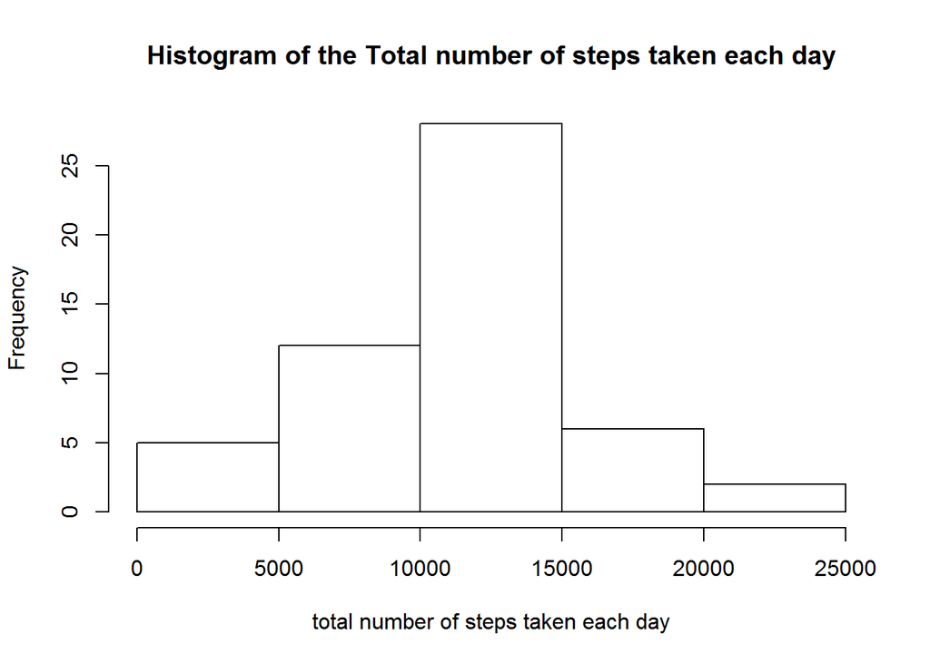

```r
hist(stepsums$`sum(steps)`, main = "Histogram of the Total number of steps taken each day", xlab = "total number of steps taken each day")
```

## Above: histogram of the total number of steps taken each day

Mean and median number of steps taken each day in this case we get rid of the NAs

```r
mean(na.omit(stepsums$`sum(steps)`))
```

```
## [1] 10766.19
```

```r
median(na.omit(stepsums$`sum(steps)`))
```

```
## [1] 10765
```

## Mean and Median

### Mean of steps taken each day is 10766.19

### Median number of steps taken each day is 10765

Make a time series plot (i.e. type = “l”) of the 5-minute interval (x-axis) and the average number of steps taken, averaged across all days (y-axis)

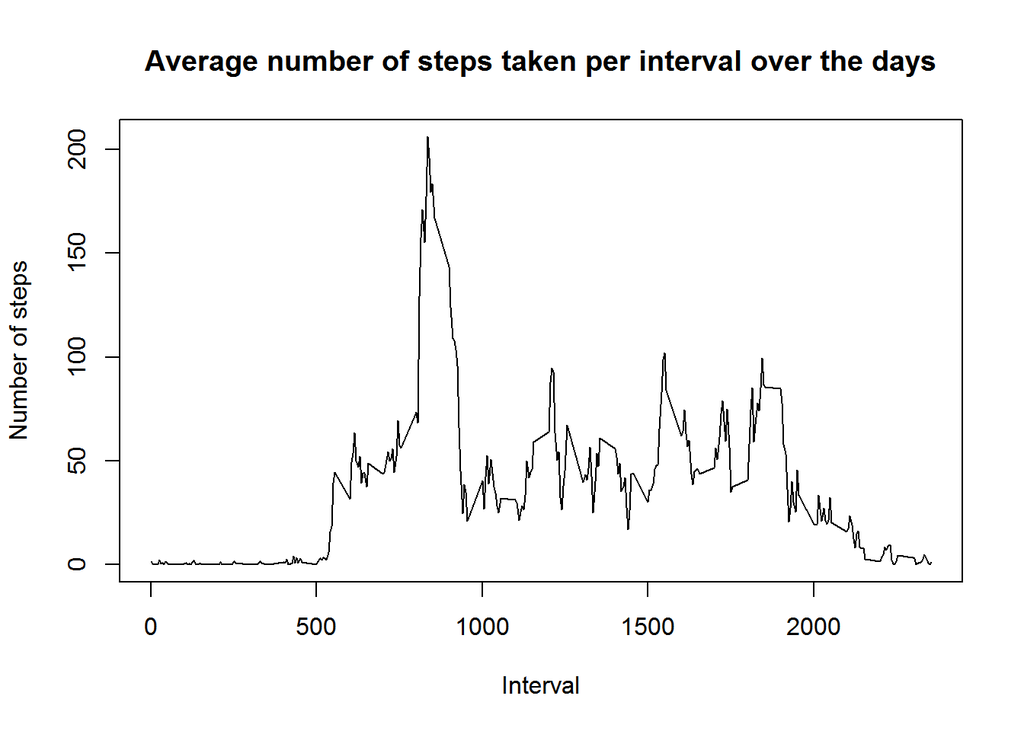

```r
# get rid of NAs in data frame
activity_df_no_na <- na.omit(activity_df)
steps_per_interval <- aggregate(steps ~ interval, activity_df_no_na, mean)
plot( steps_per_interval$interval,  steps_per_interval$steps, type="l", main = "Average number of steps taken per interval over the days", ylab="Number of steps", xlab ="Interval")
```

Which 5-minute interval, on average across all the days in the dataset, contains the maximum number of steps?

```r
steps_per_interval[which.max(steps_per_interval$steps),]
```

```
##     interval    steps
## 104      835 206.1698
```

## The interval 835 has the maximum average value of steps 206.1698

Calculate and report the total number of missing values in the dataset (i.e. the total number of rows with NAs)

```r
sum(is.na(activity_df$steps))
```

```
## [1] 2304
```

## The number of missing values in the dataset is 2304

#### Devise a strategy for filling in all of the missing values in the dataset. The strategy does not need to be sophisticated. For example, you could use the mean/median for that day, or the mean for that 5-minute interval, etc.

Strategy for imputing the missing data (steps == NA): take the average of data for that interval over all days

```r
# discover number of days
number_of_days <- nrow(stepsums)
# make a temporary copy of the data frame
activity_df_imputated <- activity_df
for (i in 1:nrow(activity_df_imputated)) {
  if (is.na(activity_df_imputated$steps[i])) {
    interval_value <- activity_df_imputated$interval[i]
    steps_value <- steps_per_interval[steps_per_interval$interval == interval_value,]
    activity_df_imputated$steps[i] <- steps_value$steps
  }
}
```

#### Now draw the imputated histogram

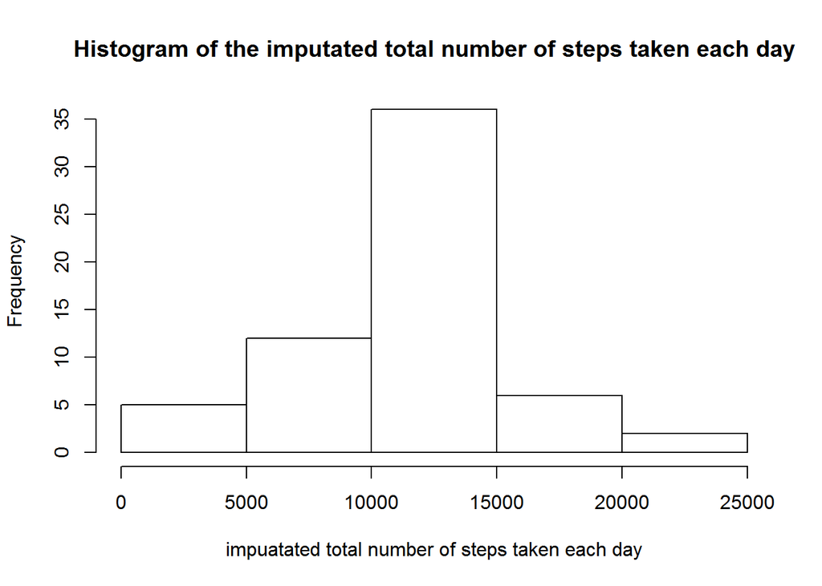

```r
gd_activity_df_imputated <- group_by(activity_df_imputated, date)
stepsums_imputated <- summarise(gd_activity_df_imputated, sum(steps))

hist(stepsums_imputated$`sum(steps)`, main = "Histogram of the imputated total number of steps taken each day", xlab = "impuatated total number of steps taken each day")
```

#### Calculate and report the mean and median total number of steps taken per day. Do these values differ from the estimates from the first part of the assignment? What is the impact of imputing missing data on the estimates of the total daily number of steps?

```r
mean(na.omit(stepsums_imputated$`sum(steps)`))
```

```
## [1] 10766.19
```

```r
median(na.omit(stepsums_imputated$`sum(steps)`))
```

```
## [1] 10766.19
```

#### The mean of the impudated steps per interval is 10766.19

#### and the median is 10766.19

#### The mean is indentical with the NAs removed. This makes sense given the way we impudated the missing values

#### Themedia changes from 10765 to 10766.19

## Are there differences in activity patterns between weekdays and weekends?

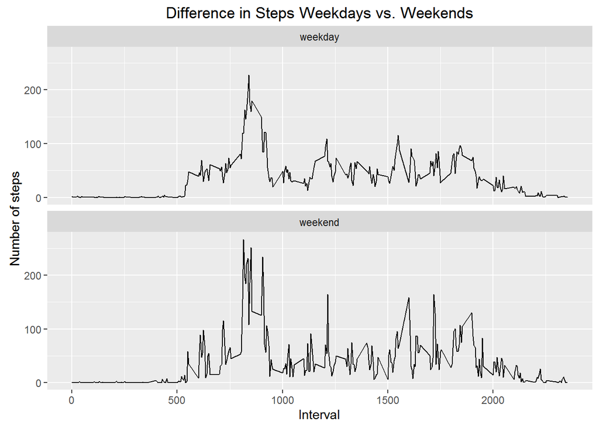

```r
# translate the data set dates to dates that weekdays can use
gooddates<-as.Date(stepsums_imputated$date, "%Y-%m-%d")
days_of_week = weekdays(gooddates)
activity_df_imputated["type_of_day"] <- as.factor(ifelse(days_of_week %in% c('Saturday','Sunday'), 'weekend', 'weekday'))
steps_per_interval_WDWE <- aggregate(steps ~ interval + type_of_day, activity_df_imputated, mean)
qplot(interval,
      steps,
      data = steps_per_interval_WDWE,
      geom=c("line"),
      xlab = "Interval",
      ylab = "Number of steps",
      main = "Difference in Steps Weekdays vs. Weekends") +
  facet_wrap(~ type_of_day, ncol = 1)
```